# Clustering Package

Luis Alfonso Pérez Martos

2020-04-23

Clustering is considered as a concise data model by which from a set of data we must partition them and introduce them in data groups, which are ́an as similar as possible. If review all clustering algorithm implements in R, can see a great number of packages that implement or improve algorithm or functionality.

The Clustering package contain multiply implementations of algorithms like: gmm, kmeans-arma, kmeans-rcpp, fuzzy_cm, fuzzy_gg, fuzzy_gk, hclust, apclusterk,aggExcluster,clara, daisy, diana,fanny,gama,mona,pam, pvclust,pvpick.

Also can use differents similarity measures to calculate the distance between points like: Euclidean, Manhattan, Jaccard, Gower, Mahalanobis, Correlation and Minkowski.

Furthermore, the package offers functions to:

- Execute different clustering algorithms.
- Metrics to evaluate clusters internal and external.

### Clustering

It’s the main method of the package.Clustering method processes a set of clustering algorithms. If we need to get information about the parameters that the method has we can do so by using the ?function or help(function). The way to load the datasets can be done in two different ways:

- If we fill in the path property we need to indicate a directory where a set of dedatasets is available.
- On the other hand, if we only need to execute a dataset that we have previously loaded in the R console, indicating to the df parameter which is the reference dataframe.

```r
df <- Clustering::clustering(df = Clustering::basketball,
                             packages = c("clusterr"), min = 4, max = 6)
```

Here we have a dataframe with the result of the execution. In it you can see all the algorithms, the similarity measures used, the variables classified in order of importance, the execution time of the algorithms and the evaluation metrics.

| Algorithm | Distance | Clusters | Dataset | Ranking | timeExternal | entropy | variation_information | precision | recall | f_measure | fowlkes_mallows_index | connectivity | dunn | silhouette | timeInternal |
| --- | --- | --- | --- | --- | --- | --- | --- | --- | --- | --- | --- | --- | --- | --- | --- |
| gmm | gmm_euclidean | 4 | dataframe | 1 | 0.0203 | 0.3161 | 4.762 | 0.1822 | 0.451 | 0.2595 | 0.2867 | 34.09 | 0.1646 | 0.23 | 0.007 |
| gmm | gmm_euclidean | 4 | dataframe | 2 | 0.0257 | 0.3085 | 4.741 | 0.1113 | 0.4005 | 0.1742 | 0.2111 | 34.09 | 0.1646 | 0.23 | 0.0071 |
| gmm | gmm_euclidean | 4 | dataframe | 3 | 0.2384 | 0.0064 | 4.72 | 0 | 0 | 0 | 0 | 34.09 | 0.1646 | 0.23 | 0.009 |
| gmm | gmm_euclidean | 4 | dataframe | 4 | 0.239 | 0.0032 | 4.143 | 0 | 0 | 0 | 0 | 34.09 | 0.1646 | 0.23 | 0.0091 |
| gmm | gmm_euclidean | 4 | dataframe | 5 | 0.3997 | 0 | 3.671 | 0 | 0 | 0 | 0 | 34.09 | 0.1646 | 0.23 | 0.0108 |
| gmm | gmm_euclidean | 5 | dataframe | 1 | 0.0245 | 0.4175 | 4.363 | 0.1637 | 0.2865 | 0.2084 | 0.2165 | 42.08 | 0.1619 | 0.25 | 0.0065 |
| gmm | gmm_euclidean | 5 | dataframe | 2 | 0.0271 | 0.3857 | 4.346 | 0.1109 | 0.2823 | 0.1592 | 0.1769 | 42.08 | 0.1619 | 0.25 | 0.0071 |
| gmm | gmm_euclidean | 5 | dataframe | 3 | 0.1838 | 0.0064 | 4.342 | 0 | 0 | 0 | 0 | 42.08 | 0.1619 | 0.25 | 0.0078 |
| gmm | gmm_euclidean | 5 | dataframe | 4 | 0.1863 | 0.0032 | 4.321 | 0 | 0 | 0 | 0 | 42.08 | 0.1619 | 0.25 | 0.0078 |
| gmm | gmm_euclidean | 5 | dataframe | 5 | 0.2108 | 0 | 4.022 | 0 | 0 | 0 | 0 | 42.08 | 0.1619 | 0.25 | 0.0153 |
| gmm | gmm_euclidean | 6 | dataframe | 1 | 0.0278 | 0.433 | 4.439 | 0.1744 | 0.2791 | 0.2147 | 0.2206 | 51.46 | 0.1619 | 0.23 | 0.0064 |
| gmm | gmm_euclidean | 6 | dataframe | 2 | 0.0289 | 0.4209 | 4.179 | 0.1062 | 0.2473 | 0.1486 | 0.1621 | 51.46 | 0.1619 | 0.23 | 0.0069 |
| gmm | gmm_euclidean | 6 | dataframe | 3 | 0.1654 | 0.0064 | 4.159 | 0 | 0 | 0 | 0 | 51.46 | 0.1619 | 0.23 | 0.0075 |
| gmm | gmm_euclidean | 6 | dataframe | 4 | 0.1811 | 0.0032 | 4.138 | 0 | 0 | 0 | 0 | 51.46 | 0.1619 | 0.23 | 0.0079 |
| gmm | gmm_euclidean | 6 | dataframe | 5 | 0.1918 | 0 | 3.954 | 0 | 0 | 0 | 0 | 51.46 | 0.1619 | 0.23 | 0.0154 |
| gmm | gmm_manhattan | 4 | dataframe | 1 | 0.0149 | 0.3161 | 4.762 | 0.1822 | 0.451 | 0.2595 | 0.2867 | 35.59 | 0.1348 | 0.23 | 0.0065 |
| gmm | gmm_manhattan | 4 | dataframe | 2 | 0.0186 | 0.3085 | 4.741 | 0.1113 | 0.4005 | 0.1742 | 0.2111 | 35.59 | 0.1348 | 0.23 | 0.0065 |
| gmm | gmm_manhattan | 4 | dataframe | 3 | 0.1536 | 0.0064 | 4.72 | 0 | 0 | 0 | 0 | 35.59 | 0.1348 | 0.23 | 0.0065 |
| gmm | gmm_manhattan | 4 | dataframe | 4 | 0.1605 | 0.0032 | 4.143 | 0 | 0 | 0 | 0 | 35.59 | 0.1348 | 0.23 | 0.0068 |
| gmm | gmm_manhattan | 4 | dataframe | 5 | 0.1839 | 0 | 3.671 | 0 | 0 | 0 | 0 | 35.59 | 0.1348 | 0.23 | 0.0069 |
| gmm | gmm_manhattan | 5 | dataframe | 1 | 0.0257 | 0.4258 | 4.35 | 0.167 | 0.2828 | 0.21 | 0.2173 | 46.83 | 0.1322 | 0.26 | 0.0072 |
| gmm | gmm_manhattan | 5 | dataframe | 2 | 0.0446 | 0.3892 | 4.338 | 0.1114 | 0.2742 | 0.1584 | 0.1747 | 46.83 | 0.1322 | 0.26 | 0.0092 |
| gmm | gmm_manhattan | 5 | dataframe | 3 | 0.1582 | 0.0064 | 4.317 | 0 | 0 | 0 | 0 | 46.83 | 0.1322 | 0.26 | 0.0116 |
| gmm | gmm_manhattan | 5 | dataframe | 4 | 0.2633 | 0.0032 | 4.296 | 0 | 0 | 0 | 0 | 46.83 | 0.1322 | 0.26 | 0.012 |
| gmm | gmm_manhattan | 5 | dataframe | 5 | 0.4502 | 0 | 4.059 | 0 | 0 | 0 | 0 | 46.83 | 0.1322 | 0.26 | 0.0301 |
| gmm | gmm_manhattan | 6 | dataframe | 1 | 0.0421 | 0.4555 | 4.298 | 0.1669 | 0.2608 | 0.2035 | 0.2085 | 54.87 | 0.1467 | 0.25 | 0.0089 |
| gmm | gmm_manhattan | 6 | dataframe | 2 | 0.0918 | 0.4052 | 4.161 | 0.1148 | 0.2606 | 0.1594 | 0.173 | 54.87 | 0.1467 | 0.25 | 0.0092 |
| gmm | gmm_manhattan | 6 | dataframe | 3 | 0.2203 | 0.0064 | 4.14 | 0 | 0 | 0 | 0 | 54.87 | 0.1467 | 0.25 | 0.0112 |
| gmm | gmm_manhattan | 6 | dataframe | 4 | 0.3068 | 0.0032 | 4.119 | 0 | 0 | 0 | 0 | 54.87 | 0.1467 | 0.25 | 0.0187 |
| gmm | gmm_manhattan | 6 | dataframe | 5 | 0.3333 | 0 | 4.102 | 0 | 0 | 0 | 0 | 54.87 | 0.1467 | 0.25 | 0.0292 |
| kmeans_arma | kmeans_arma | 4 | dataframe | 1 | 0.0009 | 0 | 0 | 0 | 0 | 0 | 0 | 44.21 | 0.1495 | 0.23 | 0.0088 |
| kmeans_arma | kmeans_arma | 4 | dataframe | 2 | 0.001 | 0 | 0 | 0 | 0 | 0 | 0 | 44.21 | 0.1495 | 0.23 | 0.009 |
| kmeans_arma | kmeans_arma | 4 | dataframe | 3 | 0.0013 | 0 | 0 | 0 | 0 | 0 | 0 | 44.21 | 0.1495 | 0.23 | 0.0099 |
| kmeans_arma | kmeans_arma | 4 | dataframe | 4 | 0.0016 | 0 | 0 | 0 | 0 | 0 | 0 | 44.21 | 0.1495 | 0.23 | 0.0103 |
| kmeans_arma | kmeans_arma | 4 | dataframe | 5 | 0.0023 | 0 | 0 | 0 | 0 | 0 | 0 | 44.21 | 0.1495 | 0.23 | 0.0128 |
| kmeans_arma | kmeans_arma | 5 | dataframe | 1 | 0.0008 | 0 | 0 | 0 | 0 | 0 | 0 | 49.22 | 0.1538 | 0.26 | 0.0082 |
| kmeans_arma | kmeans_arma | 5 | dataframe | 2 | 0.001 | 0 | 0 | 0 | 0 | 0 | 0 | 49.22 | 0.1538 | 0.26 | 0.0107 |
| kmeans_arma | kmeans_arma | 5 | dataframe | 3 | 0.0011 | 0 | 0 | 0 | 0 | 0 | 0 | 49.22 | 0.1538 | 0.26 | 0.0111 |
| kmeans_arma | kmeans_arma | 5 | dataframe | 4 | 0.0012 | 0 | 0 | 0 | 0 | 0 | 0 | 49.22 | 0.1538 | 0.26 | 0.0172 |
| kmeans_arma | kmeans_arma | 5 | dataframe | 5 | 0.0017 | 0 | 0 | 0 | 0 | 0 | 0 | 49.22 | 0.1538 | 0.26 | 0.022 |
| kmeans_arma | kmeans_arma | 6 | dataframe | 1 | 0.001 | 0 | 0 | 0 | 0 | 0 | 0 | 57.63 | 0.1619 | 0.24 | 0.0081 |
| kmeans_arma | kmeans_arma | 6 | dataframe | 2 | 0.0011 | 0 | 0 | 0 | 0 | 0 | 0 | 57.63 | 0.1619 | 0.24 | 0.0087 |
| kmeans_arma | kmeans_arma | 6 | dataframe | 3 | 0.0012 | 0 | 0 | 0 | 0 | 0 | 0 | 57.63 | 0.1619 | 0.24 | 0.0102 |
| kmeans_arma | kmeans_arma | 6 | dataframe | 4 | 0.0013 | 0 | 0 | 0 | 0 | 0 | 0 | 57.63 | 0.1619 | 0.24 | 0.0103 |
| kmeans_arma | kmeans_arma | 6 | dataframe | 5 | 0.0017 | 0 | 0 | 0 | 0 | 0 | 0 | 57.63 | 0.1619 | 0.24 | 0.0124 |
| kmeans_rcpp | kmeans_rcpp | 4 | dataframe | 1 | 0.0173 | 0.3728 | 4.627 | 0.1697 | 0.5 | 0.23 | 0.2461 | 51.04 | 0.1741 | 0.23 | 0.0073 |
| kmeans_rcpp | kmeans_rcpp | 4 | dataframe | 2 | 0.0266 | 0.3494 | 4.606 | 0.1003 | 0.3567 | 0.1511 | 0.1753 | 51.04 | 0.1741 | 0.23 | 0.0075 |
| kmeans_rcpp | kmeans_rcpp | 4 | dataframe | 3 | 0.1904 | 0.0032 | 4.606 | 0.0009 | 0.3065 | 0.0018 | 0.021 | 51.04 | 0.1741 | 0.23 | 0.0078 |
| kmeans_rcpp | kmeans_rcpp | 4 | dataframe | 4 | 0.1909 | 0.0032 | 4.531 | 0 | 0 | 0 | 0 | 51.04 | 0.1741 | 0.23 | 0.0079 |
| kmeans_rcpp | kmeans_rcpp | 4 | dataframe | 5 | 0.2305 | 0 | 3.804 | 0 | 0 | 0 | 0 | 51.04 | 0.1741 | 0.23 | 0.0143 |
| kmeans_rcpp | kmeans_rcpp | 5 | dataframe | 1 | 0.0218 | 0.4269 | 4.551 | 0.1663 | 0.5 | 0.2104 | 0.2183 | 66.85 | 0.152 | 0.19 | 0.007 |
| kmeans_rcpp | kmeans_rcpp | 5 | dataframe | 2 | 0.0233 | 0.4135 | 4.329 | 0.1019 | 0.2865 | 0.1457 | 0.1613 | 66.85 | 0.152 | 0.19 | 0.0078 |
| kmeans_rcpp | kmeans_rcpp | 5 | dataframe | 3 | 0.1641 | 0.0032 | 4.308 | 0.0011 | 0.2554 | 0.0022 | 0.0232 | 66.85 | 0.152 | 0.19 | 0.0079 |
| kmeans_rcpp | kmeans_rcpp | 5 | dataframe | 4 | 0.1798 | 0.0032 | 4.308 | 0 | 0 | 0 | 0 | 66.85 | 0.152 | 0.19 | 0.0081 |
| kmeans_rcpp | kmeans_rcpp | 5 | dataframe | 5 | 0.2077 | 0 | 4.079 | 0 | 0 | 0 | 0 | 66.85 | 0.152 | 0.19 | 0.0097 |
| kmeans_rcpp | kmeans_rcpp | 6 | dataframe | 1 | 0.0284 | 0.4545 | 4.331 | 0.1703 | 0.2458 | 0.2012 | 0.2046 | 74.78 | 0.1522 | 0.19 | 0.007 |
| kmeans_rcpp | kmeans_rcpp | 6 | dataframe | 2 | 0.0335 | 0.4169 | 4.104 | 0.1152 | 0.2419 | 0.1561 | 0.167 | 74.78 | 0.1522 | 0.19 | 0.0073 |
| kmeans_rcpp | kmeans_rcpp | 6 | dataframe | 3 | 0.1752 | 0.0064 | 4.083 | 0 | 0 | 0 | 0 | 74.78 | 0.1522 | 0.19 | 0.0074 |
| kmeans_rcpp | kmeans_rcpp | 6 | dataframe | 4 | 0.1962 | 0.0032 | 4.062 | 0 | 0 | 0 | 0 | 74.78 | 0.1522 | 0.19 | 0.0078 |
| kmeans_rcpp | kmeans_rcpp | 6 | dataframe | 5 | 0.2077 | 0 | 4.037 | 0 | 0 | 0 | 0 | 74.78 | 0.1522 | 0.19 | 0.0208 |
| mini_kmeans | mini_kmeans | 4 | dataframe | 1 | 0.001 | 0 | 0 | 0 | 0 | 0 | 0 | 50.35 | 0.1571 | 0.21 | 0.007 |
| mini_kmeans | mini_kmeans | 4 | dataframe | 2 | 0.001 | 0 | 0 | 0 | 0 | 0 | 0 | 50.35 | 0.1571 | 0.21 | 0.0071 |
| mini_kmeans | mini_kmeans | 4 | dataframe | 3 | 0.0011 | 0 | 0 | 0 | 0 | 0 | 0 | 50.35 | 0.1571 | 0.21 | 0.0072 |
| mini_kmeans | mini_kmeans | 4 | dataframe | 4 | 0.0011 | 0 | 0 | 0 | 0 | 0 | 0 | 50.35 | 0.1571 | 0.21 | 0.0073 |
| mini_kmeans | mini_kmeans | 4 | dataframe | 5 | 0.0016 | 0 | 0 | 0 | 0 | 0 | 0 | 50.35 | 0.1571 | 0.21 | 0.0077 |
| mini_kmeans | mini_kmeans | 5 | dataframe | 1 | 0.0009 | 0 | 0 | 0 | 0 | 0 | 0 | 76.4 | 0.1216 | 0.17 | 0.0073 |
| mini_kmeans | mini_kmeans | 5 | dataframe | 2 | 0.0009 | 0 | 0 | 0 | 0 | 0 | 0 | 76.4 | 0.1216 | 0.17 | 0.0074 |
| mini_kmeans | mini_kmeans | 5 | dataframe | 3 | 0.0009 | 0 | 0 | 0 | 0 | 0 | 0 | 76.4 | 0.1216 | 0.17 | 0.0076 |
| mini_kmeans | mini_kmeans | 5 | dataframe | 4 | 0.001 | 0 | 0 | 0 | 0 | 0 | 0 | 76.4 | 0.1216 | 0.17 | 0.0077 |
| mini_kmeans | mini_kmeans | 5 | dataframe | 5 | 0.0014 | 0 | 0 | 0 | 0 | 0 | 0 | 76.4 | 0.1216 | 0.17 | 0.0087 |
| mini_kmeans | mini_kmeans | 6 | dataframe | 1 | 0.0008 | 0 | 0 | 0 | 0 | 0 | 0 | 76.53 | 0.15 | 0.17 | 0.007 |
| mini_kmeans | mini_kmeans | 6 | dataframe | 2 | 0.0008 | 0 | 0 | 0 | 0 | 0 | 0 | 76.53 | 0.15 | 0.17 | 0.0072 |
| mini_kmeans | mini_kmeans | 6 | dataframe | 3 | 0.001 | 0 | 0 | 0 | 0 | 0 | 0 | 76.53 | 0.15 | 0.17 | 0.0076 |
| mini_kmeans | mini_kmeans | 6 | dataframe | 4 | 0.001 | 0 | 0 | 0 | 0 | 0 | 0 | 76.53 | 0.15 | 0.17 | 0.008 |
| mini_kmeans | mini_kmeans | 6 | dataframe | 5 | 0.0012 | 0 | 0 | 0 | 0 | 0 | 0 | 76.53 | 0.15 | 0.17 | 0.0106 |

This property tells us if we have made an internal evaluation of the groups

```
#> [1] TRUE
```

This property tells us if we have made an external evaluation of the groups

```
#> [1] TRUE
```

Algorithms executed

```
#> [1] "gmm"         "kmeans_arma" "kmeans_rcpp" "mini_kmeans"
```

Similarity Metrics

```
#> [1] "gmm_euclidean" "gmm_manhattan" "kmeans_arma"   "kmeans_rcpp"
#> [5] "mini_kmeans"
```

If we want to obtain the classified variables instead of the values we must use the variable property

```r
df_variable <- Clustering::clustering(df = Clustering::basketball,
                             packages = c("clusterr"), min = 4, max = 6, variables = TRUE)
```

| Algorithm | Distance | Clusters | Dataset | Ranking | timeExternal | entropy | variation_information | precision | recall | f_measure | fowlkes_mallows_index | connectivity | dunn | silhouette | timeInternal |
| --- | --- | --- | --- | --- | --- | --- | --- | --- | --- | --- | --- | --- | --- | --- | --- |
| gmm | gmm_euclidean | 4 | dataframe | 1 | 4 | 2 | 3 | 2 | 2 | 2 | 2 | 1 | 1 | 1 | 4 |
| gmm | gmm_euclidean | 4 | dataframe | 2 | 2 | 4 | 5 | 4 | 4 | 4 | 4 | 2 | 2 | 2 | 5 |
| gmm | gmm_euclidean | 4 | dataframe | 3 | 5 | 3 | 1 | 1 | 1 | 1 | 1 | 3 | 3 | 3 | 2 |
| gmm | gmm_euclidean | 4 | dataframe | 4 | 1 | 5 | 4 | 3 | 3 | 3 | 3 | 4 | 4 | 4 | 1 |
| gmm | gmm_euclidean | 4 | dataframe | 5 | 3 | 1 | 2 | 5 | 5 | 5 | 5 | 5 | 5 | 5 | 3 |
| gmm | gmm_euclidean | 5 | dataframe | 1 | 3 | 2 | 3 | 2 | 2 | 2 | 2 | 1 | 1 | 1 | 2 |
| gmm | gmm_euclidean | 5 | dataframe | 2 | 1 | 4 | 4 | 4 | 4 | 4 | 4 | 2 | 2 | 2 | 4 |
| gmm | gmm_euclidean | 5 | dataframe | 3 | 4 | 3 | 5 | 1 | 1 | 1 | 1 | 3 | 3 | 3 | 1 |
| gmm | gmm_euclidean | 5 | dataframe | 4 | 2 | 5 | 1 | 3 | 3 | 3 | 3 | 4 | 4 | 4 | 3 |
| gmm | gmm_euclidean | 5 | dataframe | 5 | 5 | 1 | 2 | 5 | 5 | 5 | 5 | 5 | 5 | 5 | 5 |
| gmm | gmm_euclidean | 6 | dataframe | 1 | 3 | 2 | 4 | 2 | 2 | 2 | 2 | 1 | 1 | 1 | 3 |
| gmm | gmm_euclidean | 6 | dataframe | 2 | 1 | 4 | 3 | 4 | 4 | 4 | 4 | 2 | 2 | 2 | 5 |
| gmm | gmm_euclidean | 6 | dataframe | 3 | 4 | 3 | 5 | 1 | 1 | 1 | 1 | 3 | 3 | 3 | 1 |
| gmm | gmm_euclidean | 6 | dataframe | 4 | 2 | 5 | 1 | 3 | 3 | 3 | 3 | 4 | 4 | 4 | 2 |
| gmm | gmm_euclidean | 6 | dataframe | 5 | 5 | 1 | 2 | 5 | 5 | 5 | 5 | 5 | 5 | 5 | 4 |
| gmm | gmm_manhattan | 4 | dataframe | 1 | 5 | 2 | 3 | 2 | 2 | 2 | 2 | 1 | 1 | 1 | 2 |
| gmm | gmm_manhattan | 4 | dataframe | 2 | 1 | 4 | 5 | 4 | 4 | 4 | 4 | 2 | 2 | 2 | 1 |
| gmm | gmm_manhattan | 4 | dataframe | 3 | 3 | 3 | 1 | 1 | 1 | 1 | 1 | 3 | 3 | 3 | 4 |
| gmm | gmm_manhattan | 4 | dataframe | 4 | 2 | 5 | 4 | 3 | 3 | 3 | 3 | 4 | 4 | 4 | 5 |
| gmm | gmm_manhattan | 4 | dataframe | 5 | 4 | 1 | 2 | 5 | 5 | 5 | 5 | 5 | 5 | 5 | 3 |
| gmm | gmm_manhattan | 5 | dataframe | 1 | 5 | 2 | 4 | 2 | 2 | 2 | 2 | 1 | 1 | 1 | 3 |
| gmm | gmm_manhattan | 5 | dataframe | 2 | 1 | 4 | 3 | 4 | 4 | 4 | 4 | 2 | 2 | 2 | 2 |
| gmm | gmm_manhattan | 5 | dataframe | 3 | 3 | 3 | 5 | 1 | 1 | 1 | 1 | 3 | 3 | 3 | 4 |
| gmm | gmm_manhattan | 5 | dataframe | 4 | 2 | 5 | 1 | 3 | 3 | 3 | 3 | 4 | 4 | 4 | 5 |
| gmm | gmm_manhattan | 5 | dataframe | 5 | 4 | 1 | 2 | 5 | 5 | 5 | 5 | 5 | 5 | 5 | 1 |
| gmm | gmm_manhattan | 6 | dataframe | 1 | 4 | 2 | 4 | 2 | 4 | 2 | 2 | 1 | 1 | 1 | 2 |
| gmm | gmm_manhattan | 6 | dataframe | 2 | 1 | 4 | 3 | 4 | 2 | 4 | 4 | 2 | 2 | 2 | 1 |
| gmm | gmm_manhattan | 6 | dataframe | 3 | 5 | 3 | 5 | 1 | 1 | 1 | 1 | 3 | 3 | 3 | 3 |
| gmm | gmm_manhattan | 6 | dataframe | 4 | 2 | 5 | 1 | 3 | 3 | 3 | 3 | 4 | 4 | 4 | 5 |
| gmm | gmm_manhattan | 6 | dataframe | 5 | 3 | 1 | 2 | 5 | 5 | 5 | 5 | 5 | 5 | 5 | 4 |
| kmeans_arma | kmeans_arma | 4 | dataframe | 1 | 5 | 1 | 1 | 1 | 1 | 1 | 1 | 1 | 1 | 1 | 5 |
| kmeans_arma | kmeans_arma | 4 | dataframe | 2 | 3 | 2 | 2 | 2 | 2 | 2 | 2 | 2 | 2 | 2 | 2 |
| kmeans_arma | kmeans_arma | 4 | dataframe | 3 | 4 | 3 | 3 | 3 | 3 | 3 | 3 | 3 | 3 | 3 | 4 |
| kmeans_arma | kmeans_arma | 4 | dataframe | 4 | 2 | 4 | 4 | 4 | 4 | 4 | 4 | 4 | 4 | 4 | 3 |
| kmeans_arma | kmeans_arma | 4 | dataframe | 5 | 1 | 5 | 5 | 5 | 5 | 5 | 5 | 5 | 5 | 5 | 1 |
| kmeans_arma | kmeans_arma | 5 | dataframe | 1 | 5 | 1 | 1 | 1 | 1 | 1 | 1 | 1 | 1 | 1 | 1 |
| kmeans_arma | kmeans_arma | 5 | dataframe | 2 | 2 | 2 | 2 | 2 | 2 | 2 | 2 | 2 | 2 | 2 | 3 |
| kmeans_arma | kmeans_arma | 5 | dataframe | 3 | 3 | 3 | 3 | 3 | 3 | 3 | 3 | 3 | 3 | 3 | 4 |
| kmeans_arma | kmeans_arma | 5 | dataframe | 4 | 1 | 4 | 4 | 4 | 4 | 4 | 4 | 4 | 4 | 4 | 5 |
| kmeans_arma | kmeans_arma | 5 | dataframe | 5 | 4 | 5 | 5 | 5 | 5 | 5 | 5 | 5 | 5 | 5 | 2 |
| kmeans_arma | kmeans_arma | 6 | dataframe | 1 | 3 | 1 | 1 | 1 | 1 | 1 | 1 | 1 | 1 | 1 | 5 |
| kmeans_arma | kmeans_arma | 6 | dataframe | 2 | 1 | 2 | 2 | 2 | 2 | 2 | 2 | 2 | 2 | 2 | 3 |
| kmeans_arma | kmeans_arma | 6 | dataframe | 3 | 5 | 3 | 3 | 3 | 3 | 3 | 3 | 3 | 3 | 3 | 4 |
| kmeans_arma | kmeans_arma | 6 | dataframe | 4 | 2 | 4 | 4 | 4 | 4 | 4 | 4 | 4 | 4 | 4 | 1 |
| kmeans_arma | kmeans_arma | 6 | dataframe | 5 | 4 | 5 | 5 | 5 | 5 | 5 | 5 | 5 | 5 | 5 | 2 |
| kmeans_rcpp | kmeans_rcpp | 4 | dataframe | 1 | 3 | 4 | 5 | 2 | 3 | 2 | 2 | 1 | 1 | 1 | 4 |
| kmeans_rcpp | kmeans_rcpp | 4 | dataframe | 2 | 1 | 2 | 1 | 4 | 2 | 4 | 4 | 2 | 2 | 2 | 5 |
| kmeans_rcpp | kmeans_rcpp | 4 | dataframe | 3 | 4 | 3 | 3 | 3 | 4 | 3 | 3 | 3 | 3 | 3 | 3 |
| kmeans_rcpp | kmeans_rcpp | 4 | dataframe | 4 | 2 | 5 | 4 | 1 | 1 | 1 | 1 | 4 | 4 | 4 | 1 |
| kmeans_rcpp | kmeans_rcpp | 4 | dataframe | 5 | 5 | 1 | 2 | 5 | 5 | 5 | 5 | 5 | 5 | 5 | 2 |
| kmeans_rcpp | kmeans_rcpp | 5 | dataframe | 1 | 3 | 2 | 4 | 2 | 3 | 2 | 2 | 1 | 1 | 1 | 4 |
| kmeans_rcpp | kmeans_rcpp | 5 | dataframe | 2 | 1 | 4 | 5 | 4 | 2 | 4 | 4 | 2 | 2 | 2 | 5 |
| kmeans_rcpp | kmeans_rcpp | 5 | dataframe | 3 | 4 | 3 | 1 | 3 | 4 | 3 | 3 | 3 | 3 | 3 | 3 |
| kmeans_rcpp | kmeans_rcpp | 5 | dataframe | 4 | 2 | 5 | 3 | 1 | 1 | 1 | 1 | 4 | 4 | 4 | 2 |
| kmeans_rcpp | kmeans_rcpp | 5 | dataframe | 5 | 5 | 1 | 2 | 5 | 5 | 5 | 5 | 5 | 5 | 5 | 1 |
| kmeans_rcpp | kmeans_rcpp | 6 | dataframe | 1 | 4 | 2 | 4 | 2 | 2 | 2 | 2 | 1 | 1 | 1 | 2 |
| kmeans_rcpp | kmeans_rcpp | 6 | dataframe | 2 | 1 | 4 | 3 | 4 | 4 | 4 | 4 | 2 | 2 | 2 | 5 |
| kmeans_rcpp | kmeans_rcpp | 6 | dataframe | 3 | 3 | 3 | 5 | 1 | 1 | 1 | 1 | 3 | 3 | 3 | 1 |
| kmeans_rcpp | kmeans_rcpp | 6 | dataframe | 4 | 2 | 5 | 1 | 3 | 3 | 3 | 3 | 4 | 4 | 4 | 4 |
| kmeans_rcpp | kmeans_rcpp | 6 | dataframe | 5 | 5 | 1 | 2 | 5 | 5 | 5 | 5 | 5 | 5 | 5 | 3 |
| mini_kmeans | mini_kmeans | 4 | dataframe | 1 | 2 | 1 | 1 | 1 | 1 | 1 | 1 | 1 | 1 | 1 | 1 |
| mini_kmeans | mini_kmeans | 4 | dataframe | 2 | 1 | 2 | 2 | 2 | 2 | 2 | 2 | 2 | 2 | 2 | 4 |
| mini_kmeans | mini_kmeans | 4 | dataframe | 3 | 5 | 3 | 3 | 3 | 3 | 3 | 3 | 3 | 3 | 3 | 2 |
| mini_kmeans | mini_kmeans | 4 | dataframe | 4 | 3 | 4 | 4 | 4 | 4 | 4 | 4 | 4 | 4 | 4 | 5 |
| mini_kmeans | mini_kmeans | 4 | dataframe | 5 | 4 | 5 | 5 | 5 | 5 | 5 | 5 | 5 | 5 | 5 | 3 |
| mini_kmeans | mini_kmeans | 5 | dataframe | 1 | 4 | 1 | 1 | 1 | 1 | 1 | 1 | 1 | 1 | 1 | 1 |
| mini_kmeans | mini_kmeans | 5 | dataframe | 2 | 3 | 2 | 2 | 2 | 2 | 2 | 2 | 2 | 2 | 2 | 3 |
| mini_kmeans | mini_kmeans | 5 | dataframe | 3 | 2 | 3 | 3 | 3 | 3 | 3 | 3 | 3 | 3 | 3 | 2 |
| mini_kmeans | mini_kmeans | 5 | dataframe | 4 | 5 | 4 | 4 | 4 | 4 | 4 | 4 | 4 | 4 | 4 | 5 |
| mini_kmeans | mini_kmeans | 5 | dataframe | 5 | 1 | 5 | 5 | 5 | 5 | 5 | 5 | 5 | 5 | 5 | 4 |
| mini_kmeans | mini_kmeans | 6 | dataframe | 1 | 3 | 1 | 1 | 1 | 1 | 1 | 1 | 1 | 1 | 1 | 1 |
| mini_kmeans | mini_kmeans | 6 | dataframe | 2 | 5 | 2 | 2 | 2 | 2 | 2 | 2 | 2 | 2 | 2 | 5 |
| mini_kmeans | mini_kmeans | 6 | dataframe | 3 | 4 | 3 | 3 | 3 | 3 | 3 | 3 | 3 | 3 | 3 | 2 |
| mini_kmeans | mini_kmeans | 6 | dataframe | 4 | 1 | 4 | 4 | 4 | 4 | 4 | 4 | 4 | 4 | 4 | 3 |
| mini_kmeans | mini_kmeans | 6 | dataframe | 5 | 2 | 5 | 5 | 5 | 5 | 5 | 5 | 5 | 5 | 5 | 4 |

If we only want to obtain the best classified variables or values for the external variables we execute the following method:

```r
df_best_ranked_external <- Clustering::best_ranked_external_metrics(df$result)
```

| Algorithm | Distance | Clusters | Dataset | Ranking | timeExternal | entropy | variation_information | precision | recall | f_measure | fowlkes_mallows_index |
| --- | --- | --- | --- | --- | --- | --- | --- | --- | --- | --- | --- |
| gmm | gmm_euclidean | 4 | dataframe | 1 | 0.0203 | 0.3161 | 4.762 | 0.1822 | 0.451 | 0.2595 | 0.2867 |
| gmm | gmm_euclidean | 5 | dataframe | 1 | 0.0245 | 0.4175 | 4.363 | 0.1637 | 0.2865 | 0.2084 | 0.2165 |
| gmm | gmm_euclidean | 6 | dataframe | 1 | 0.0278 | 0.433 | 4.439 | 0.1744 | 0.2791 | 0.2147 | 0.2206 |
| gmm | gmm_manhattan | 4 | dataframe | 1 | 0.0149 | 0.3161 | 4.762 | 0.1822 | 0.451 | 0.2595 | 0.2867 |
| gmm | gmm_manhattan | 5 | dataframe | 1 | 0.0257 | 0.4258 | 4.35 | 0.167 | 0.2828 | 0.21 | 0.2173 |
| gmm | gmm_manhattan | 6 | dataframe | 1 | 0.0421 | 0.4555 | 4.298 | 0.1669 | 0.2608 | 0.2035 | 0.2085 |
| kmeans_arma | kmeans_arma | 4 | dataframe | 1 | 0.0009 | 0 | 0 | 0 | 0 | 0 | 0 |
| kmeans_arma | kmeans_arma | 5 | dataframe | 1 | 0.0008 | 0 | 0 | 0 | 0 | 0 | 0 |
| kmeans_arma | kmeans_arma | 6 | dataframe | 1 | 0.001 | 0 | 0 | 0 | 0 | 0 | 0 |
| kmeans_rcpp | kmeans_rcpp | 4 | dataframe | 1 | 0.0173 | 0.3728 | 4.627 | 0.1697 | 0.5 | 0.23 | 0.2461 |
| kmeans_rcpp | kmeans_rcpp | 5 | dataframe | 1 | 0.0218 | 0.4269 | 4.551 | 0.1663 | 0.5 | 0.2104 | 0.2183 |
| kmeans_rcpp | kmeans_rcpp | 6 | dataframe | 1 | 0.0284 | 0.4545 | 4.331 | 0.1703 | 0.2458 | 0.2012 | 0.2046 |
| mini_kmeans | mini_kmeans | 4 | dataframe | 1 | 0.001 | 0 | 0 | 0 | 0 | 0 | 0 |
| mini_kmeans | mini_kmeans | 5 | dataframe | 1 | 0.0009 | 0 | 0 | 0 | 0 | 0 | 0 |
| mini_kmeans | mini_kmeans | 6 | dataframe | 1 | 0.0008 | 0 | 0 | 0 | 0 | 0 | 0 |

We also obtain the best classified values for internal evaluation

```r
df_best_ranked_internal <- Clustering::best_ranked_internal_metrics(df$result)
```

| Algorithm | Distance | Clusters | Dataset | Ranking | timeInternal | connectivity | dunn | silhouette |
| --- | --- | --- | --- | --- | --- | --- | --- | --- |
| gmm | gmm_euclidean | 4 | dataframe | 1 | 0.007 | 34.09 | 0.1646 | 0.23 |
| gmm | gmm_euclidean | 5 | dataframe | 1 | 0.0065 | 42.08 | 0.1619 | 0.25 |
| gmm | gmm_euclidean | 6 | dataframe | 1 | 0.0064 | 51.46 | 0.1619 | 0.23 |
| gmm | gmm_manhattan | 4 | dataframe | 1 | 0.0065 | 35.59 | 0.1348 | 0.23 |
| gmm | gmm_manhattan | 5 | dataframe | 1 | 0.0072 | 46.83 | 0.1322 | 0.26 |
| gmm | gmm_manhattan | 6 | dataframe | 1 | 0.0089 | 54.87 | 0.1467 | 0.25 |
| kmeans_arma | kmeans_arma | 4 | dataframe | 1 | 0.0088 | 44.21 | 0.1495 | 0.23 |
| kmeans_arma | kmeans_arma | 5 | dataframe | 1 | 0.0082 | 49.22 | 0.1538 | 0.26 |
| kmeans_arma | kmeans_arma | 6 | dataframe | 1 | 0.0081 | 57.63 | 0.1619 | 0.24 |
| kmeans_rcpp | kmeans_rcpp | 4 | dataframe | 1 | 0.0073 | 51.04 | 0.1741 | 0.23 |
| kmeans_rcpp | kmeans_rcpp | 5 | dataframe | 1 | 0.007 | 66.85 | 0.152 | 0.19 |
| kmeans_rcpp | kmeans_rcpp | 6 | dataframe | 1 | 0.007 | 74.78 | 0.1522 | 0.19 |
| mini_kmeans | mini_kmeans | 4 | dataframe | 1 | 0.007 | 50.35 | 0.1571 | 0.21 |
| mini_kmeans | mini_kmeans | 5 | dataframe | 1 | 0.0073 | 76.4 | 0.1216 | 0.17 |
| mini_kmeans | mini_kmeans | 6 | dataframe | 1 | 0.007 | 76.53 | 0.15 | 0.17 |

In order to obtain the best evaluation by algorithm

```r
df_best_validation_external <- Clustering::evaluate_best_validation_external_by_metrics(df$result)
```

| Algorithm | Distance | timeExternal | entropy | variation_information | precision | recall | f_measure | fowlkes_mallows_index |
| --- | --- | --- | --- | --- | --- | --- | --- | --- |
| gmm | gmm_euclidean | 0.0278 | 0.433 | 4.762 | 0.1822 | 0.451 | 0.2595 | 0.2867 |
| gmm | gmm_manhattan | 0.0421 | 0.4555 | 4.762 | 0.1822 | 0.451 | 0.2595 | 0.2867 |
| kmeans_arma | kmeans_arma | 0.001 | 0 | 0 | 0 | 0 | 0 | 0 |
| kmeans_rcpp | kmeans_rcpp | 0.0284 | 0.4545 | 4.627 | 0.1703 | 0.5 | 0.23 | 0.2461 |
| mini_kmeans | mini_kmeans | 0.001 | 0 | 0 | 0 | 0 | 0 | 0 |

Based on the results obtained we can see that the gmm algorithm behaves better.

From the algorithm with the best rating we can select the most appropriate number of clusters.

```r
df_result_external <- Clustering::result_external_algorithm_by_metric(df$result,"gmm")
```

| Algorithm | Clusters | timeExternal | entropy | variation_information | precision | recall | f_measure | fowlkes_mallows_index |
| --- | --- | --- | --- | --- | --- | --- | --- | --- |
| gmm | 4 | 0.0203 | 0.3161 | 4.762 | 0.1822 | 0.451 | 0.2595 | 0.2867 |
| gmm | 5 | 0.0257 | 0.4258 | 4.363 | 0.167 | 0.2865 | 0.21 | 0.2173 |
| gmm | 6 | 0.0421 | 0.4555 | 4.439 | 0.1744 | 0.2791 | 0.2147 | 0.2206 |

The same checks performed for external evaluation metrics, we can perform for internal evaluation.

```r
df_best_validation_internal <-
  Clustering::evaluate_best_validation_internal_by_metrics(df$result)
```

| Algorithm | Distance | timeInternal | connectivity | dunn | silhouette |
| --- | --- | --- | --- | --- | --- |
| gmm | gmm_euclidean | 0.007 | 51.46 | 0.1646 | 0.25 |
| gmm | gmm_manhattan | 0.0089 | 54.87 | 0.1467 | 0.26 |
| kmeans_arma | kmeans_arma | 0.0088 | 57.63 | 0.1619 | 0.26 |
| kmeans_rcpp | kmeans_rcpp | 0.0073 | 74.78 | 0.1741 | 0.23 |
| mini_kmeans | mini_kmeans | 0.0073 | 76.53 | 0.1571 | 0.21 |

In this case we can see that depending on the evaluation you want to make, one algorithm or another is chosen.

If we want to see graphically the representation of any metric as a function of the number of clusters and algorithm we can do it in the following way depending if the evaluation metric is internal or external

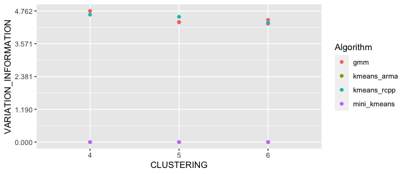

```r
Clustering::plot_external_validation(df,"variation_information")
```